# Tutorial

The lower boundary condition is set by `FreeDrain` in `createsoilplist`. If `TRUE`, water drains freely from the bottom of the profile under gravity, representing a deep, well-drained soil. If `FALSE`, the lower boundary is held at saturation, representing a water table at the base of the profile.

At each timestep, `SoilWaterModel` accounts for rainfall, surface evaporation and water movement between layers, as well as root water uptake where plants are present. Below, we simulate bare ground over the first 10 days of June, coupling the soil water, heat and canopy models. As before, we initialise the soil profile using `createsoilplist` and `InitSoilheatmod`, with water content increasing from 0.28 at the surface to 0.36 at depth. `InitSoilwatermod` then initialises the soil water model, with free drainage at the lower boundary.

Each hour, `soilrelhum` calculates relative humidity at the soil surface from its temperature and water content. `solve_wholecanopy` then provides absorbed radiation and the resistance to heat and water vapour transfer between the surface and reference height. `SoilHeatModel` uses these to update soil temperatures and ground heat flux, while `SoilWaterModel` calculates evaporation and redistribution of water between soil layers from the updated temperatures, rainfall and atmospheric conditions. Transpiration (`Et`) is set to zero because the ground is bare. The updated water contents are passed back to the heat model, since soil thermal properties depend on moisture. These calculations are repeated until ground heat flux converges, after which the temperatures and water contents are stored and the updated soil state is carried forward to the next hour.

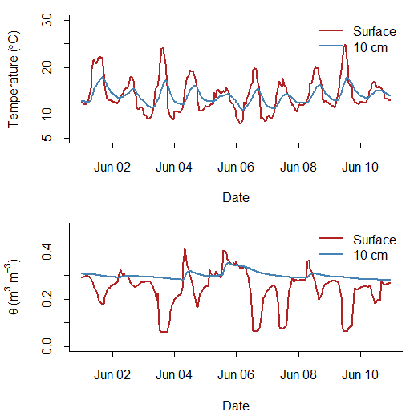

```r
# ---------------- Load example forcing and parameter datasets ------------ #
weather <- climdata # meteorological forcing data
groundp <- micropoint::groundparams # ground surface parameters

vegp <- createplant_inputs("C3")
vegp$h <- 0 # vegetation height (m): zero for bare ground
vegp$pai <- 0 # plant area index: zero for bare ground

lat <- 49.96807 # latitude (decimal degrees)
long <- -5.215668 # longitude (decimal degrees)

boundaryT <- mean(weather$temp) # lower soil boundary temperature (°C)

# ---------------- Select first 10 days of June -------------------------- #
tme <- as.POSIXlt(weather$obs_time, tz = "UTC")
sel <- which(tme$mon + 1 == 6 &
             tme$mday < 11)
weather <- weather[sel,]
tme <- tme[sel]

# ---------------------- Create soil parameter set ----------------------- #
soilp <- createsoilplist(soiltype = "Clay loam",
                         nlayers = 15, # number of soil layers
                         totalDepth = 2, # total soil depth (m)
                         slope = 0, # slope (degrees)
                         aspect = 180, # aspect (degrees)
                         surface_organicmu = 1, # surface organic matter depth
                         FreeDrain = TRUE) # free drainage lower boundary

n <- length(soilp$b) # number of depths: one more than the number of layers

# ---------------------- Initialise soil profiles ------------------------ #
Te <- seq(weather$temp[1],
          boundaryT,
          length.out = n) # initial temperature profile (°C)
theta <- seq(0.28,
             0.36,
             length.out = n) # initial soil water profile
soilheat <- InitSoilheatmod(soilp,
                            Te,
                            theta) # initialise soil heat model
soilwater <- InitSoilwatermod(soilp,
                              soilheat,
                              root50 = vegp$root50, # rooting depths (m): not
                              root95 = vegp$root95) # used without transpiration

# Identify depth closest to 10 cm
nd <- which.min(abs(soilheat$z - 0.1))

# ------------------------- Initialise outputs --------------------------- #
Tsurface <- T10cm <- theta_surface <- theta_10cm <- rep(NA, 240)
G <- 0 # initial ground heat flux estimate
error <- 1e99 # convergence criterion

# --------------------------- Main simulation loop ----------------------- #
for (hr in 1:240) {
  itr <- 1
  # Iteratively solve soil heat and soil water balance
  while (error > 1e-2 && itr < 20) {
    # ------------- Relative humidity of air at the soil surface -------- #
    soilrh <- soilrelhum(soilwater$theta[1], # surface water content
                         soilheat$Te[1], # surface temperature (°C)
                         soilp$psie[1], # air-entry water potential
                         soilp$b[1], # Campbell shape parameter
                         soilp$Smax[1]) # saturation water content

    # ------- Absorbed radiation and resistance to heat transfer -------- #
    can <- solve_wholecanopy(weather,
                             vegp,
                             groundp,
                             hr,
                             lat,
                             long,
                             zref = 2,
                             G,
                             theta = soilwater$theta[1],
                             soilrh = soilrh)

    # ----------------------- Solve soil heat transport ----------------- #
    soilheat <- SoilHeatModel(soilheat,
                              soilp,
                              Rabs = can$Rabs, # absorbed radiation (W m^-2)
                              Tref = weather$temp[hr], # air temperature (°C)
                              relhum = weather$relhum[hr], # relative humidity (%)
                              atmPressure = weather$pres[hr], # pressure (kPa)
                              rHa = can$rHg) # resistance from ground to zref (s m^-1)

    error <- abs(G - soilheat$Gflux) # convergence error
    G <- soilheat$Gflux

    # ----------------------- Assemble forcing data --------------------- #
    forcing <- list(Tair = weather$temp[hr], # air temperature (°C)
                    relhum = weather$relhum[hr], # relative humidity (%)
                    rHa = can$rHg, # resistance from ground to zref (s m^-1)
                    precip = weather$precip[hr], # precipitation (mm h^-1)
                    Et = 0) # transpiration (mm h^-1): none from bare ground

    # ----------------------- Solve soil water movement ----------------- #
    soilwater$Tc <- soilheat$Te
    soilwater$oldTc <- soilheat$oldTe

    soilwater <- SoilWaterModel(soilwater,
                                soilp,
                                forcing)

    # Update thermal properties using new soil moisture
    soilheat$wc <- soilwater$theta
    itr <- itr + 1
  }

  # ---------------------------- Store outputs -------------------------- #
  Tsurface[hr] <- soilheat$Te[1]
  T10cm[hr] <- soilheat$Te[nd]

  theta_surface[hr] <- soilwater$theta[1]
  theta_10cm[hr] <- soilwater$theta[nd]

  # State at the end of the hour becomes that at the start of the next
  soilheat$oldTe <- soilheat$Te
  soilwater$oldvapor <- soilwater$vapor
  soilwater$oldtheta <- soilwater$theta

  error <- 1e99 # reset convergence criterion
}

# --------------------------- Plot time series --------------------------- #
par(mfrow = c(2, 1))
tmec <- as.POSIXct(tme, tz = "UTC")
# Soil temperature time series
plot(Tsurface ~ tmec, type = "l",
     lwd = 2,
     col = "firebrick",
     ylim = c(5, 30),
     xlab = "Date",
     ylab = expression("Temperature (" * degree * "C)"))
lines(T10cm ~ tmec, lwd = 2, col = "steelblue")
legend("topright",
       legend = c("Surface", "10 cm"),
       col = c("firebrick", "steelblue"),
       lwd = 2,
       bty = "n")
# Soil moisture time series
plot(theta_surface ~ tmec, type = "l",
     lwd = 2,
     col = "firebrick",
     ylim = c(0, 0.5),
     xlab = "Date",
     ylab = expression(theta ~ "(m"^3 * " m"^-3 * ")"))
lines(theta_10cm ~ tmec, lwd = 2, col = "steelblue")
legend("topright",
       legend = c("Surface", "10 cm"),
       col = c("firebrick", "steelblue"),
       lwd = 2,
       bty = "n")
```

Surface temperature varies strongly through the day, while temperature at 10 cm changes less and peaks later. Surface water content also falls during the day as water evaporates, then recovers overnight as water moves upwards from wetter soil below. Rainfall on 4–5 June brings the surface close to saturation. At 10 cm, moisture changes more gradually, rising after rainfall before declining as water drains deeper into the profile.

In this bare-soil example, water is lost through evaporation and drainage. Where vegetation is present, `SoilWaterModel` also distributes root water uptake between layers according to root density. Because transpiration depends on stomatal conductance, which itself responds to soil moisture, the canopy and soil water models must be solved together. This coupling is handled by `micropoint`.

## Snow

Snow cover affects microclimate in three main ways: it reflects much of the incoming sunlight, insulates the soil beneath from the air above, and stores water that is released when it melts. Modelling snow therefore requires us to track both heat and water within the snowpack.

As with soil, the snowpack is divided into vertical layers, ordered from the surface downwards. Each layer has its own thickness, density, temperature, age and snow water equivalent (SWE), the amount of water it contains expressed as an equivalent depth in mm. `InitSnowModel` creates a snowpack with layers 1 cm thick near the surface, where temperature changes fastest, increasing to 3 cm below. Snow density is calculated using `SnowDensFun`. Fresh snow is relatively light but becomes denser as it ages and as additional snow accumulates above it. The rate of densification depends on the kind of snow, which varies with climate. Following Sturm et al. (2010), five snow environments are recognised, and `SnowDensParams` returns the parameters for each: `Maritime`, the deep, relatively warm and wet snow of mild coastal mountains, which becomes dense quickly; `Alpine`, the deep, cold snow of high mountains; `Prairie`, the thin, wind-blown snow of open grassland; `Tundra`, the thin, cold, wind-packed snow of treeless country at high latitudes; and `Taiga`, the cold snow of sheltered boreal forest, which stays light and loose. The examples below use `Maritime`.

### Snow energy balance

The energy balance of a snow surface broadly follows the same principles as that of any other surface: it absorbs and emits radiation, exchanges sensible and latent heat with the air, and conducts heat into the material below. Where vegetation stands above the snow, the radiation reaching it is that which passes through the canopy, as described for the ground beneath a canopy. Three features distinguish snow.

The first is its **albedo**. Fresh snow reflects around 85% of incoming shortwave radiation, far more than soil or vegetation. Albedo declines as snow ages: fine ice crystals grow into larger, rounder grains, impurities accumulate, and surface roughness increases, all tending to increase absorption. `SnowAlbedo` represents these effects as a decline with the logarithm of snow age. The example below shows how albedo changes over 60 days.

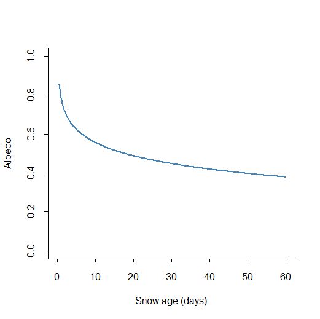

```r
snowage <- seq(0, 60 * 24, length.out = 500) # age of the snow (hours)
alb <- SnowAlbedo(snowage)
par(mfrow = c(1, 1))
plot(alb ~ I(snowage / 24), type = "l",
     col = "steelblue",
     lwd = 2,
     ylim = c(0, 1),
     xlab = "Snow age (days)",
     ylab = "Albedo")
```

The second is its effect on **aerodynamic resistance**, which determines how readily heat and water vapour are exchanged with the air. Snow is smoother than bare ground, raises the surface towards the height at which weather is measured, and progressively buries vegetation. This changes both the roughness of the surface and the extent to which vegetation shelters it from the wind. `SnowResistance` accounts for these effects and returns the resistance to heat transfer and friction velocity.

The third is that **snow containing ice cannot warm above 0 °C**. `snowsurfaceEB` calculates the exchange of radiation, sensible and latent heat in much the same way as `soilsurfaceEB`, but assumes that the air immediately above the snow is saturated and limits its temperature to 0 °C. Once snow reaches this temperature, additional energy goes into melting rather than further warming.

Heat storage within the snowpack is handled by `SnowSoilHeatModel`. This combines the snow layers and underlying soil into a single column, solving heat conduction between adjacent layers using the same approach described for the soil temperature model. Snow is a poor conductor of heat, particularly when its density is low, as calculated by `SnowThermalConductivity`. Consequently, even a relatively shallow snowpack can insulate the soil from large fluctuations in air temperature. When a snow layer reaches 0 °C, its temperature is held there and any additional energy is made available for melting.

### Snow mass balance

Alongside heat exchange, we need to account for snow accumulation, melting and water movement. `SnowMassBalance` updates the snowpack at each timestep through five processes:

1. **Snowfall and rainfall.** Precipitation falls as snow when air temperature is at or below 0 °C, rain at or above 2 °C, and a mixture between. New snow forms a layer at the surface.
2. **Melting.** Energy available for melting from the heat model reduces the amount of snow held in each layer.
3. **Rain-induced melting.** Rain falling on snow can cause additional melting as it cools to 0 °C.
4. **Sublimation and deposition.** Water vapour exchange removes snow by sublimation when the air is dry, or adds frost when conditions favour deposition.
5. **Liquid water movement.** Rain and meltwater percolate downwards through the snowpack. Water entering layers below 0 °C can refreeze, releasing heat and warming the snow. The snowpack can retain liquid water up to 5% of its snow water equivalent, with any excess draining from its base.

Snow depth and density change as these processes operate. To keep the numerical representation manageable, `RegulariseSnowLayers` merges layers thinner than 5 mm and splits those thicker than 5 cm. This maintains relatively fine layers without allowing their number or thickness to become impractical.

### Snow model

We can now combine the energy and mass balance calculations to simulate the development of a snowpack over a month. Snow is rare at the location represented by our weather data, so we take January weather, reduce air temperature by 9 °C and adjust downward longwave radiation to reflect the colder conditions. We start with bare ground and no snow, allowing the snowpack to accumulate and melt in response to the modified weather.

The code runs the model in hourly steps:

1. **Surface properties and radiation.** When snow is present, the surface takes the albedo, emissivity and roughness of snow; otherwise, it retains those of bare soil. These properties determine how much radiation is absorbed.
2. **Aerodynamic resistance.** `SnowResistance` calculates resistance to heat transfer and friction velocity, accounting for snow depth, surface roughness and atmospheric stability.
3. **Heat transfer.** `SnowSoilHeatModel` calculates temperatures throughout the snowpack and underlying soil, together with the energy available for melting.
4. **Atmospheric stability.** The sensible heat flux is calculated from the difference between surface and air temperature. This is used to update the Obukhov length, which affects aerodynamic resistance in the following hour.
5. **Snow accumulation and loss.** `SnowMassBalance` updates snowfall, sublimation, melting, refreezing and drainage. `RegulariseSnowLayers` then adjusts the thickness and number of snow layers.
6. **Advance the model.** Snow depth, temperatures and water fluxes are stored, and the updated snow and soil temperatures become the starting conditions for the next hour.

For simplicity, soil moisture is held constant in this example. In a fully coupled model, water draining from the base of the snowpack would enter `SoilWaterModel`, allowing snowmelt to influence soil moisture and subsequent evaporation and transpiration.

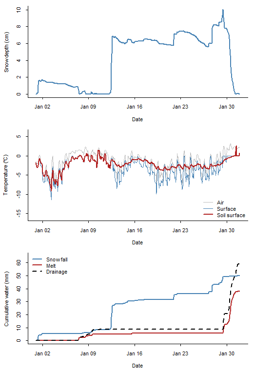

```r
# ---------------- Load example forcing data ------------------------------ #
weather <- climdata # meteorological forcing data

# ------------------------ Select data for January ----------------------- #
tme <- as.POSIXlt(weather$obs_time, tz = "UTC")
sel <- which(tme$mon + 1 == 1)
weather <- weather[sel,]
tme <- tme[sel]

# Reduce air temperature by 9 °C to give snow, and reduce longwave
# radiation from the sky to that of air colder by the same amount
temp_new <- weather$temp - 9
weather$lwdown <- weather$lwdown *
  ((temp_new + 273.15) / (weather$temp + 273.15))^4
weather$temp <- temp_new

# ---------------------- Create soil parameter set ----------------------- #
soilp <- createsoilplist(soiltype = "Clay loam",
                         nlayers = 15, # number of soil layers
                         totalDepth = 2, # total soil depth (m)
                         slope = 0, # slope (degrees)
                         aspect = 180, # aspect (degrees)
                         surface_organicmu = 1, # surface organic matter depth
                         FreeDrain = TRUE) # free drainage lower boundary
n <- length(soilp$b) # number of depths: one more than the number of layers

# --------------------------- Initialise models -------------------------- #
Te <- seq(0, 4, length.out = n) # initial soil temperature profile (°C)
theta <- rep(0.3, n) # volumetric soil water content
soilheat <- InitSoilheatmod(soilp, Te, theta) # initialise soil heat model
snowmod <- InitSnowModel(snowdepth = 0, # no snow to begin with
                         snowage = 0,
                         snowtemp = 0)

# ------------------------- Initialise outputs --------------------------- #
nhrs <- nrow(weather)
snowdepth <- surfacetemp <- soiltemp <- snowfall <- melt <- drainage <- rep(0, nhrs)
LL <- Inf # Obukhov length (m): neutral air to begin with

# --------------------- Run model in hourly timesteps -------------------- #
for (hr in 1:nhrs) {
  depth <- sum(snowmod$depth) # snow depth (m)

  # ---------------- Properties of the surface: snow or soil ------------- #
  if (depth > 0) {
    alb <- SnowAlbedo(snowmod$age[1]) # albedo, from the age of the surface snow
    em <- 0.99 # emissivity of snow
    z0 <- 0.002 # roughness length of snow (m)
  } else {
    alb <- soilp$gref # albedo of the soil
    em <- soilp$groundem # emissivity of the soil
    z0 <- 0.004 # roughness length of bare ground (m)
  }

  # ------------------------ Absorbed radiation ------------------------- #
  Rabs <- (1 - alb) * weather$swdown[hr] +
          em * weather$lwdown[hr] # absorbed radiation (W m^-2)

  # ----------- Resistance to heat transfer and friction velocity ------- #
  res <- SnowResistance(depth,
                        hgt = 0, # vegetation height (m)
                        pai = 0, # plant area index
                        uref = weather$windspeed[hr], # wind speed (m s^-1)
                        zref = 2, # reference height (m)
                        LL = LL, # Obukhov length (m)
                        z0 = z0)

  # ------------- Solve coupled snow-soil heat transfer ---------------- #
  snowsoil <- SnowSoilHeatModel(snowmod,
                                soilheat,
                                soilp,
                                Rabs,
                                Tref = weather$temp[hr], # air temperature (°C)
                                relhum = weather$relhum[hr], # relative humidity (%)
                                atmPressure = weather$pres[hr], # pressure (kPa)
                                rHa = res$rHa)
  snowmod <- snowsoil$snowmod
  soilheat <- snowsoil$soilheatmod

  # Surface temperature: that of the soil, or of snow no warmer than 0 °C
  if (depth > 0) {
    Tsurface <- min(snowmod$temp[1], 0)
  } else {
    Tsurface <- soilheat$Te[1]
  }

  # --------------------- Compute atmospheric stability ---------------- #
  ph <- rhoair(weather$temp[hr],
               weather$pres[hr]) # air density (mol m^-3)
  cp <- cpair(weather$temp[hr]) # heat capacity of air
  H <- (ph * cp / res$rHa) *
       (Tsurface - weather$temp[hr]) # sensible heat flux (W m^-2)
  LL <- Obukhov(weather$temp[hr],
                weather$pres[hr],
                res$uf,
                H) # Obukhov length, used in the next hour

  # ----------------------- Run snow mass balance ---------------------- #
  forcing <- list(Tair = weather$temp[hr], # air temperature (°C)
                  relhum = weather$relhum[hr], # relative humidity (%)
                  pk = weather$pres[hr], # pressure (kPa)
                  rHa = res$rHa, # resistance to heat transfer (s m^-1)
                  precip = weather$precip[hr]) # precipitation (mm h^-1)
  snowmod <- SnowMassBalance(snowmod,
                             forcing,
                             snowenv = "Maritime")

  # -------------------- Regularise snow layer structure ---------------- #
  snowmod <- RegulariseSnowLayers(snowmod)

  # ---------------------------- Store outputs -------------------------- #
  snowdepth[hr] <- sum(snowmod$depth) # snow depth (m)
  surfacetemp[hr] <- Tsurface # temperature of the snow or soil surface (°C)
  soiltemp[hr] <- soilheat$Te[1] # temperature of the soil surface (°C)
  snowfall[hr] <- snowmod$snowfall # snow added (mm)
  melt[hr] <- snowmod$melt + snowmod$rainmelt # snow melted (mm)
  drainage[hr] <- snowmod$throughfall # water leaving the base of the snow (mm)

  # State at the end of the hour becomes that at the start of the next
  snowmod$oldtemp <- snowmod$temp
  soilheat$oldTe <- soilheat$Te
}

# ----------------------------- Plot results ------------------------------ #
par(mfrow = c(3, 1))
tmec <- as.POSIXct(tme, tz = "UTC")

# Snow depth
plot(I(snowdepth * 100) ~ tmec, type = "l",
     col = "steelblue",
     lwd = 2,
     xlab = "Date",
     ylab = "Snow depth (cm)")

# Temperature of the air, the surface and the soil surface
plot(weather$temp ~ tmec, type = "l",
     col = "grey",
     ylim = c(-16, 6),
     xlab = "Date",
     ylab = expression("Temperature (" * degree * "C)"))
lines(surfacetemp ~ tmec, col = "steelblue")
lines(soiltemp ~ tmec, col = "firebrick", lwd = 2)
legend("bottomright",
       legend = c("Air", "Surface", "Soil surface"),
       col = c("grey", "steelblue", "firebrick"),
       lwd = c(1, 1, 2),
       bty = "n")

# Water added as snow, melted, and leaving the base of the snow
plot(cumsum(snowfall) ~ tmec, type = "l",
     col = "steelblue",
     lwd = 2,
     ylim = c(0, 65),
     xlab = "Date",
     ylab = "Cumulative water (mm)")
lines(cumsum(melt) ~ tmec, col = "firebrick", lwd = 2)
lines(cumsum(drainage) ~ tmec, col = "black", lwd = 2, lty = 2)
legend("topleft",
       legend = c("Snowfall", "Melt", "Drainage"),
       col = c("steelblue", "firebrick", "black"),
       lty = c(1, 1, 2),
       lwd = 2,
       bty = "n")
```

The simulation produces two periods of snow cover. A light snowfall on 1 January leaves less than 2 cm, which gradually disappears by the 8th. A heavier fall on 12 January produces around 7 cm, which persists through a cold spell and is topped up by further snowfall on the 27th and 28th. The snowpack then melts rapidly at the end of the month as air temperatures rise above freezing and rain falls on the snow.

The insulating effect is particularly clear in the middle panel. The temperature of the snow surface is determined by its energy balance. On cold nights the snow emits more longwave radiation than it receives, and its surface falls several degrees below air temperature, reaching around -10 °C. By day it reflects most of the incoming sunlight, and its temperature cannot rise above 0 °C. Beneath the thin snow of early January, the soil surface is almost as cold. Under 6–7 cm of snow, however, soil temperature remains relatively stable at around -2 to -4 °C, despite fluctuations of around 10 °C at the snow surface. The lower panel shows that little snow melts until the final thaw, when meltwater and rain drain rapidly from the base of the snowpack.

### Canopy snow interception

In forests, not all snowfall reaches the ground. Some is intercepted by branches and foliage, where it may subsequently sublimate directly into the atmosphere, melt or fall to the ground. This can substantially reduce the amount of snow accumulating beneath the canopy, affecting both the insulating effect of snow cover and the amount of water entering the soil when it melts.

To model this, we need to calculate how much snow the canopy intercepts and how much it subsequently releases. The function `CanopySnowInterception`, based on Hedstrom & Pomeroy (1998), accounts for the amount of vegetation available to catch snow, wind speed (which affects the angle at which snow falls through the canopy), and the amount already stored. As snow accumulates, the canopy’s remaining storage capacity declines. The maximum load is controlled by Sh, the amount of snow that can be held per unit branch area. The function returns the snow intercepted during each timestep, the amount falling from the canopy to the ground, and the snow remaining in the canopy.

Below, we use `CanopySnowInterception` to show how the fraction of a 5 mm snowfall intercepted by an initially snow-free canopy varies with plant area index.

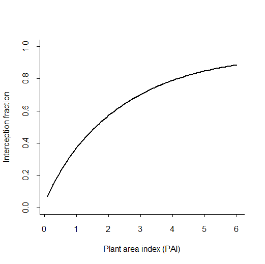

```r
# Vary canopy plant area index
pai_seq <- seq(0.1, 6, length.out = 100) # plant area index

# Compute snow caught by the canopy (mm SWE)
interception <- CanopySnowInterception(hgt = 8, # canopy height (m)
                                       pai = pai_seq,
                                       uf = 0.3, # friction velocity (m s^-1)
                                       prec = 5, # snowfall amount (mm SWE)
                                       tc = -5, # air temperature (°C)
                                       Li = 0)$intercepted # no snow held to begin with

# Convert to fraction of snowfall intercepted
frac_intercepted <- interception / 5

# ----------------------------- Plot results ------------------------------ #
par(mfrow = c(1, 1))
plot(pai_seq, frac_intercepted,
     type = "l",
     lwd = 2,
     ylim = c(0, 1),
     xlab = "Plant area index (PAI)",
     ylab = "Interception fraction")
```

Interception increases rapidly with plant area index, then begins to level off once most of the falling snow meets the canopy. Sparse canopies intercept little snow, whereas dense canopies can retain a large fraction of a snowfall event before unloading or throughfall return it to the ground.

## Animal energy budgets

In this section we present some simple approaches for computing the body temperature of ectotherms and, for endotherms, the heat they must produce, or lose by evaporation, to hold their body temperature near-constant. The animal is represented geometrically as a triaxial ellipsoid defined by its length, width, and height, providing a flexible but tractable approximation that allows key physical properties such as volume, surface area, and directional exposure to sunshine and wind to be calculated. These quantities underpin all components of their energy budget. Radiative exchange depends on how the body interacts with directional (direct) and hemispheric (diffuse and longwave) fluxes, convective heat loss depends on the characteristic dimension of the body relative to airflow, and metabolic heat production depends on body size and temperature.

The following sections describe how these components are calculated. We first consider radiation absorption, including the role of body orientation in determining interception of direct solar radiation. We then derive the resistance to heat loss via convection, followed by formulations for metabolic heat production. These components are finally combined to solve for body temperature in ectotherms and, in endotherms, for the heat production or evaporation needed to hold body temperature near-constant, together with a physiologically equivalent temperature.

### Radiation absorption

In our animal models, absorbed radiation is calculated from upward and downward shortwave and longwave fluxes, with absorption determined by surface reflectance and body geometry. Diffuse shortwave and longwave radiation are treated as hemispheric fluxes: the upper half of the body receives the downward fluxes from the sky, and the lower half the upward fluxes reflected and emitted by the ground, except where the body touches the ground, which exchanges heat with it by conduction instead. In contrast, direct shortwave radiation is directional, so absorption depends on the area of the body projected perpendicular to the solar beam. This is equivalent to the size of the shadow cast onto a surface perpendicular to the sunlight. For example, a standing person casts a small shadow onto the ground when the sun is overhead, but a larger one onto a wall behind them when facing the evening sun. We account for this using the `silhouette` function, which calculates the ratio of projected area to total body surface area from solar geometry and body orientation. This dimensionless coefficient determines the fraction of direct solar radiation, expressed relative to a surface perpendicular to the beam, intercepted per unit body surface area.

The example below illustrates how interception of direct solar radiation varies over a midsummer day for a person standing upright and facing south (`adir = 180`). Solar zenith and azimuth angles are calculated for daylight hours, and the body is represented using typical adult dimensions (height = 170 cm, width = 45 cm, length = 25 cm), with width corresponding to shoulder breadth and length to front–back depth. Body tilt is set to zero (upright). The `silhouette` function calculates how the interception coefficient changes as the sun moves across the sky. Note that the geometry is symmetric: exchanging height and length and setting body tilt to 90° gives an equivalent configuration, since interception depends on the orientation of the body’s principal axes relative to the sun, rather than how those axes are labelled.

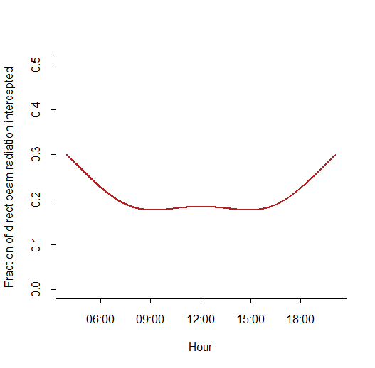

```r
# Calculate solar zenith and azimuth as function of time of day
tme <- as.POSIXlt((0:1439) * 60,
                  origin = "2025-06-21 00:00",
                  tz = "UTC")
solp <- sunposition(tme,
                    lat = 50,
                    long = 0)
# Select daylight hours only
sel <- which(solp$zen < 90)
tme <- tme[sel]
solp <- sunposition(tme,
                    lat = 50,
                    long = 0)

# Calculate fraction of direct radiation intercepted by an upright
# human facing south
height <- 170 # height (cm)
width <- 45 # width (cm)
len <- 25 # body depth (cm)
svals <- silhouette(solp$zen,
                    solp$azi,
                    height,
                    width,
                    len,
                    adir = 180, # facing south (degrees)
                    atilt = 0.0, # upright posture
                    position = "fixed")

# ----------------------------- Plot results ------------------------------ #
par(mfrow = c(1, 1))
plot(svals$SolarCoef ~ as.POSIXct(tme),
     type = "l",
     col = "firebrick",
     lwd = 2,
     ylim = c(0, 0.5),
     xlab = "Hour",
     ylab = "Fraction of direct beam radiation intercepted")
```

The `position` argument controls how body orientation is specified. When `fixed`, the body maintains a constant orientation defined by `adir` - the direction from north in which the animal is facing and `atilt` - the angle by which the front of the body is raised, which tilts its height axis from the vertical by the same angle. The options `max` and `min` instead assume that the body adopts the orientation that maximises or minimises interception of direct radiation at each time step, representing extreme behavioural thermoregulation. The `randomdir` option assumes the body rotates freely in the horizontal plane (i.e. azimuth is random) while maintaining a fixed tilt, whereas `random` assumes both azimuth and tilt are random, giving an orientation-averaged interception. Together, these options provide a simple way to represent a range of behavioural and postural assumptions, from fixed orientation through to fully random or optimised alignment with the solar beam.

### Resistance to heat loss

As for leaves, resistance to sensible heat loss depends on body size, with larger animals developing thicker boundary layers and therefore exchanging heat less efficiently. For animals, however, the relevant dimension for convection also depends on orientation, because the characteristic dimension is typically taken as body volume divided by the area projected normal to the airflow. The same animal can therefore have different boundary layer resistances depending on how it is aligned relative to the wind.

We calculate projected area using the `silhouette` function. Although designed for radiation, the same geometry can be used here by treating the wind as a horizontal beam, so that the projected area normal to flow is obtained from the body shape and orientation. This projected area is then used to derive the characteristic dimension supplied to `animalrHa`, which computes boundary layer resistance from standard forced- and free-convection relationships.

The example below shows how boundary layer resistance varies with orientation relative to the wind for a simple animal geometry. We first set the animal dimensions, assign a range of directions and then compute the characteristic dimension as a function of the orientation in which it is facing. Finally, we plot both the characteristic dimension and resistance as a function of orientation.

[figure not shown]

```r
# Animal geometry (cm)
height <- 12 # height (cm)
width <- 8 # width (cm)
len <- 25 # length (cm)

# Orientation relative to wind direction
adir <- seq(0, 180, by = 1) # orientation angle (degrees)

# Characteristic dimension (m)
d <- chardim(wdir = 0, # wind direction (degrees)
             height,
             width,
             len,
             adir,
             atilt = 0, # body tilt angle (degrees)
             position = "fixed")

# Boundary layer resistance at fixed conditions
rHa <- sapply(d, function(dd) {
  animalrHa(tair = 20, # air temperature (°C)
            dT = 5, # body-air temperature difference (°C)
            uz = 1, # wind speed (m s^-1)
            d = dd) # characteristic dimension (m)
})

# ----------------------------- Plot results ------------------------------ #
par(mfrow = c(2, 1),
    mar = c(5, 5, 2, 2))
plot((d * 100) ~ adir,
     type = "l",
     lwd = 2,
     ylim = c(0, 25),
     xlab = "Orientation relative to wind direction (degrees)",
     ylab = "Characteristic dimension (cm)")
plot(rHa ~ adir,
     type = "l",
     lwd = 2,
     ylim = c(0, 150),
     xlab = "Orientation relative to wind direction (degrees)",
     ylab = expression("Boundary layer resistance (s m"^-1 * ")"))
```

The characteristic dimension and hence also the resistance to heat loss is lowest when the animal is side-on to the direction of the wind. Here the wind crosses the body from one side to the other, so the distance it travels over the surface is short and the boundary layer remains thin. Conversely, when the animal is aligned with the wind, this distance is greater, allowing a thicker boundary layer to develop and increasing resistance to heat loss.

### Metabolic rates

Metabolic heat production forms one component of the animal energy balance. In ectotherms it is often small relative to radiative and convective fluxes, but can still influence body temperature, particularly in larger or more active animals. In endotherms, by contrast, metabolism is typically the dominant heat source and must offset environmental heat loss.

In the tutorial, the metabolic rate is calculated using the `metabolic_rate` function and depends on body mass and body temperature. Mass is obtained from volume and density. The function returns metabolic heat production in watts, which the energy balance divides by surface area so that it is comparable with the other terms.

For ectotherms, metabolic rate is controlled by four parameters: a normalisation constant (`a0`), a mass-scaling exponent (`b`), a temperature sensitivity (`Q10`), and a reference temperature (`Tref`). The exponent `b` determines how metabolism scales with body size and typically lies close to 0.7–0.8. The parameter `Q10` controls how rapidly metabolism increases with temperature, with values around 2–3 common for ectotherms, implying an approximate doubling or tripling of metabolic rate per 10 °C. The normalisation constant `a0` sets the overall magnitude of metabolic rate at the reference temperature, and therefore captures differences among taxa and activity levels. Together, these parameters define how strongly metabolic heat production responds to both size and temperature.

The `create_ectop` function in the `micropoint` package assembles these parameters for different ectotherm types alongside body geometry and surface properties. Body dimensions are used to estimate volume and surface area assuming an ellipsoid, while defaults are assigned for traits such as density, emissivity, thermal conductivity, resistance of the skin to water loss and conductive contact with the substrate. These defaults vary by organism type (e.g. arthropod, reptile, amphibian), but can be modified as needed.

For endotherms, body temperature is held nearly constant, so the temperature term plays no part. Basal metabolic rate depends on body mass alone, and the `create_endop` function sets it from Kleiber’s relation: about 3.4 W for a 1 kg animal, rising with mass to the power 0.75. Metabolism is the main heat source in the endotherm energy balance, and what matters is how far it must rise above this basal rate to hold body temperature in the cold.

In the example below, we show how the metabolic rate of a typically-sized reptile varies as a function of its body temperature.

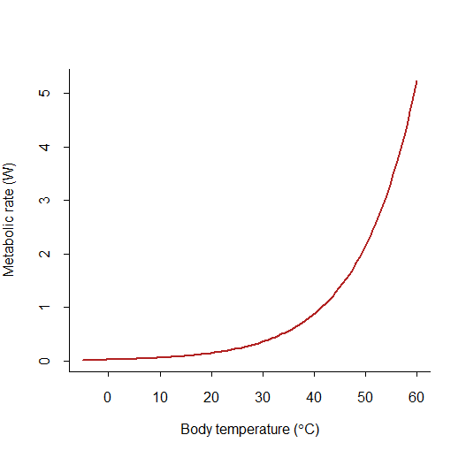

```r
require(micropoint) # ensure micropoint package is installed
# Animal geometry (cm)
height <- 12 # height (cm)
width <- 8 # width (cm)
len <- 25 # length (cm)

# Create ectotherm parameter set
ecto_params <- micropoint::create_ectop(height,
                                        width,
                                        len,
                                        refl = 0.1, # body reflectance
                                        adir = 0, # orientation angle (degrees)
                                        position = "randomdir", # random orientation
                                        type = "reptile") # ectotherm type

# Assign variable body temperature
Tbody <- seq(-5, 60, length.out = 100) # body temperature (°C)

# Compute metabolic rate
met_rate <- with(ecto_params,
                 metabolic_rate(volume, # body volume (m^3)
                                rho, # body density (kg m^-3)
                                Q10, # temperature sensitivity coefficient
                                a0, # allometric intercept
                                b, # allometric exponent
                                Tref, # reference temperature (°C)
                                Tbody))

# ----------------------------- Plot results ------------------------------ #
par(mfrow = c(1, 1))
plot(met_rate ~ Tbody,
     type = "l",
     col = "firebrick",
     lwd = 2,
     xlab = expression("Body temperature (" * degree * "C)"),
     ylab = expression("Metabolic rate (W)"))
```

### Ectotherms

The components described above are combined in the `Ectothermtemp` function, which calculates ectotherm body temperature for a single time step. It takes the animal’s traits, held in the `ecto_params` object returned by `create_ectop`, and `microcdata`, a list of the microclimate conditions experienced by the animal at that time step: single values of air temperature, humidity and wind at the animal’s height, the temperature and humidity of the ground surface it rests on, and the shortwave and longwave radiation reaching it from above and below.

Several terms in the energy balance, such as convective heat exchange and metabolic heat production, themselves depend on body temperature. The function therefore iterates internally, updating these terms until its estimate of body temperature settles.

To derive the variables in `microcdata`, we first need to run a microclimate model. Here, we use the methods introduced in previous sections to calculate hourly microclimate conditions for a small reptile on bare ground in June. The ground surface energy balance and soil heat model are solved iteratively because heat exchange between the ground surface and underlying soil depends on both. We then calculate air temperature, humidity, wind and radiation at the reptile’s height and combine these into `microcdata`. Finally, we pass these conditions to `Ectothermtemp` to calculate the reptile’s body temperature.

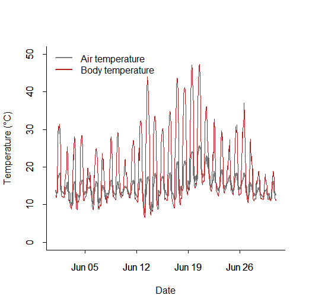

```r
# -------------------- Create June weather dataset ------------------------- #
# Reload the weather dataset: the name climdata is reused for model driving variables
climdata <- microclimlearn::climdata
weather <- climdata

# Select data for June
tme <- as.POSIXlt(weather$obs_time, tz = "UTC")
sel <- which(tme$mon + 1 == 6)
weather <- weather[sel,]
tme <- tme[sel]

# -------------------- Create vegetation parameter set -------------------- #
# Bare ground
vegp <- createplant_inputs("C3")
vegp$h <- 0     # vegetation height (m): zero for bare ground
vegp$pai <- 0   # plant area index: zero for bare ground

# -------------------- Create soil datasets and initialise models --------- #
groundp <- micropoint::groundparams

# Lower soil boundary temperature
boundaryT <- 11.36071

soilp <- createsoilplist(
  soiltype = "Clay loam",
  nlayers = 15,
  totalDepth = 2,
  slope = 0,
  aspect = 180,
  surface_organicmu = 1,
  FreeDrain = TRUE
)

# Number of soil layers
n <- length(soilp$b)

# Initial soil temperature profile
Te <- seq(weather$temp[1], boundaryT, length.out = n)

# Initial soil water content profile
theta <- seq(0.2, soilp$Smax[n], length.out = n)

# Initialise soil heat model
soilheat <- InitSoilheatmod(soilp, Te, theta)

# -------------------- Create ectotherm parameter set --------------------- #
ecto_params <- micropoint::create_ectop(
  height = 12,
  width = 8,
  len = 25,
  refl = 0.1,
  adir = 0,
  position = "randomdir",
  type = "reptile"
)

# -------------------- Run model in hourly timesteps ---------------------- #
Tbody <- G <- Tsurface <- 0

for (hr in 1:720) {

  # Initialise convergence criterion
  error <- 1e99
  itr <- 1

  # Solve the ground surface and the soil alternately until the ground heat
  # flux settles
  while (error > 1e-2 && itr < 20) {

    # -------------------- Run microclimate model ------------------------ #

    # Estimate relative humidity at soil surface (percentage)
    soilrh <- soilrelhum(
      0.2,              # volumetric water content at the surface
      soilheat$Te[1],   # soil surface temperature (°C)
      soilp$psi_e[1],   # air-entry water potential (J/kg)
      soilp$b[1],       # Campbell shape parameter
      soilp$Smax[1]     # water content at saturation
    )

    # Solve the energy balance of the ground surface
    can <- solve_wholecanopy(
      weather,
      vegp,
      groundp,
      hr,
      49.96807,
      -5.215668,
      zref = 2,
      G,
      theta = 0.2,
      soilrh = soilrh
    )

    # -------------------- Solve soil heat transport --------------------- #

    soilheat <- SoilHeatModel(
      soilheat,
      soilp,
      Rabs = can$Rabs,               # radiation absorbed by the ground
      Tref = weather$temp[hr],
      relhum = weather$relhum[hr],
      atmPressure = weather$pres[hr],
      rHa = can$rHg                  # resistance from ground to zref
    )

    # Update convergence criterion
    error <- abs(G - soilheat$Gflux)
    G <- soilheat$Gflux
    itr <- itr + 1
  }

  # Move the soil model on to the next time step
  soilheat$oldTe <- soilheat$Te

  # --------- Calculate conditions 6 cm above the ground surface --------- #

  # Resistance to heat transfer between the ground surface and 6 cm
  r6 <- canopyresistance(0.06, can$uf, vegp$h, vegp$pai, can$LL)

  # Air temperature at 6 cm: the share of the temperature difference between
  # ground and reference height that lies above 6 cm
  Tz <- weather$temp[hr] +
    (can$tcanopy - weather$temp[hr]) *
    ((can$rHa - r6) / can$rHa)

  # Vapour pressures
  es <- satvap(can$tcanopy)
  ea <- satvap(weather$temp[hr]) *
    (weather$relhum[hr] / 100)

  # Vapour pressure at 6 cm, where vapour from the ground also meets the
  # resistance of the soil surface
  ez <- ea +
    (es - ea) *
    (can$rHa - r6) / (can$rHa + can$rS)

  # Relative humidity at 6 cm
  Rhz <- pmin((ez / satvap(Tz)) * 100, 100)

  # Wind speed at 6 cm
  uz <- windprofile_above(0.06, can$uf, vegp$h, vegp$pai, can$LL)

  # --------- Calculate upward and downward radiation fluxes ------------ #

  # Solar geometry
  solp <- sunposition(
    tme[hr],
    lat = 49.96807,
    long = -5.215668
  )

  # Surface albedo
  albs <- albedo(
    vegp$pai,
    vegp$lref,
    vegp$ltra,
    vegp$x,
    groundp$gref,
    groundp$slope,
    groundp$aspect,
    solp
  )

  # Compute direct and reflected shortwave radiation
  if (weather$swdown[hr] > 0) {

    Rdirdown <- (weather$swdown[hr] -
      weather$difrad[hr]) /
      cos(solp$zen * pi / 180)

    Rswup <- albs$albd * weather$difrad[hr] +
      Rdirdown * cos(solp$zen * pi / 180) *
      albs$albb

  } else {

    Rdirdown <- Rswup <- 0
  }

  # ---------------- Calculate ectotherm body temperature --------------- #

  microcdata <- list(
    Tair = Tz,
    Tsurf = can$tcanopy,
    relhum = Rhz,
    surfrelhum = soilrh,
    pk = weather$pres[hr],
    windspeed = uz,
    winddir = weather$winddir[hr],
    Rdirdown = Rdirdown,
    Rdifdown = weather$difrad[hr],
    Rswup = Rswup,
    Rlwdown = weather$lwdown[hr],
    # longwave emitted by the ground and sky longwave it reflects
    Rlwup = groundp$em * 5.67e-8 * (can$tcanopy + 273.15)^4 +
      (1 - groundp$em) * weather$lwdown[hr]
  )

  # Solve ectotherm heat balance
  Tbody[hr] <- Ectothermtemp(
    ecto_params,
    tme[hr],
    microcdata,
    lat = 49.96807,
    long = -5.215668
  )
}

# ------------------------- Plot temperatures ----------------------------- #
tmec <- as.POSIXct(tme)

# Air temperature
plot(
  weather$temp ~ tmec,
  type = "l",
  xlab = "Date",
  ylab = "Temperature (°C)",
  ylim = c(0, 50),
  col = rgb(0, 0, 0, 0.5),
  lwd = 2
)

# Ectotherm body temperature
par(new = TRUE)

plot(
  Tbody ~ tmec,
  type = "l",
  xlab = "",
  ylab = "",
  ylim = c(0, 50),
  col = "firebrick"
)

# Add legend
legend(
  "topleft",
  legend = c("Air temperature", "Body temperature"),
  col = c(rgb(0, 0, 0, 0.5), "firebrick"),
  lwd = 2,
  bty = "n"
)
```

In the plot, the red line shows predicted body temperature and the grey line the air temperature at 2 m from the weather data. The two differ because its microenvironment differs from macroclimate and the animal’s body itself has an energy budget, for example being heated by sunlight.

### Endotherms

Birds and mammals maintain a relatively stable core temperature by regulating heat production and loss. Their thermal balance differs from that of an ectotherm because the temperature of the body surface can be very different from that of the core. We provide two endotherm models, which look at the same animal from complementary perspectives. The first, `Endotherm`, assumes the animal holds its core temperature constant and asks what that costs: how much extra metabolic heat it must expend when it is cold, or how much latent heat it must lose by evaporation when it is hot, and whether either is more than it can achieve. The latent heat loss can optionally be expressed as the water this requires. The second, `EndothermPET`, instead holds the animal’s heat production fixed and lets its core and skin temperatures respond to its surroundings. From those temperatures it calculates how hot or cold the surroundings feel to the animal, expressed as a physiologically equivalent temperature (PET). Both models treat the body in the same way: heat flows from the core, through tissue and coat, to the surroundings and to the ground. We first describe the parts they share, then each model in turn.

In endotherms, heat moves between the core and the environment through body tissues and the coat of fur or feathers, before being exchanged with the surroundings by convection and radiation. Each stage offers resistance to heat flow and in steady state these successive resistances are analogous to current through electrical resistors in series: the greater the resistance, the larger the temperature difference needed to carry a given heat flux. Thus, the surface of a well-insulated coat can be much cooler than the animal’s core, and it is this outer surface that exchanges sensible and radiative heat with the surroundings. The resistance of the tissues between core and skin is calculated by `tissueresistance`, which accounts for heat produced within the body. It depends on body size and tissue conductivity, which varies as blood vessels near the skin constrict or dilate. The resistance of the coat is calculated by `coatresistance` from its depth and effective thermal conductivity, accounting for heat transfer through air, hairs or feathers, and radiation within the coat. At the outer surface of the coat, heat is exchanged with the surroundings by convection and radiation. Rather than calculating these exchanges separately, we can combine their effects by calculating something known as the operative temperature: the temperature of a uniform environment that would produce the same heat exchange with the coat surface. The function `operativetemp` calculates this temperature and the associated resistance to heat loss, using the convective boundary-layer resistance from `animalrHa` and an equivalent resistance for radiation. Both endotherm models use these calculations to account for the effects of sunlight, wind and longwave radiation.

#### Maintaining constant body temperature

The `Endotherm` function calculates what the animal must do to keep its core temperature constant: the heat it must produce or dissipate. Heat transfer between the core and the surroundings depends on the difference between core and operative temperature and the sum of the resistances. Three broad responses are possible. Below the thermoneutral zone, even maximum tissue insulation is insufficient to retain the heat generated by basal metabolism, so metabolic heat production must increase. Within the thermoneutral zone, basal metabolism is sufficient and heat loss can be regulated by changing blood flow to the skin. Above it, sensible and radiative exchange cannot dispose of basal heat production even at minimum tissue resistance, so additional evaporative cooling is required, through panting or sweating where available.

To make these calculations, `Endotherm` needs information about the animal’s size, insulation and capacity to regulate heat production and loss. These parameters are assembled by `create_endop`. Users specify body dimensions, coat depth, whether the animal is a bird or mammal, coat reflectance, sweating ability and whether it is standing or lying. The remaining parameters needed to run `Endotherm` are estimated from published relationships, although any value can be changed in the returned list. Body mass is estimated from body dimensions, and basal metabolic rate from mass using Kleiber’s (1947) relation. The maximum sustainable metabolic rate is set at six times basal, within the range of four to eight times basal measured in mammals and birds (Minnaar et al. 2014). Core temperature is set at 37 °C for mammals and 41 °C for birds. An upper survivable limit is set 5 °C higher, consistent with the observation that birds and mammals seldom exceed 46 °C (Freeman et al. 2020), while the lower limit is 20 °C, below which cardiac function fails in non-hibernating mammals. Coat insulation is assumed to increase in proportion to coat depth, as Scholander et al. (1950) found across arctic and tropical mammals, using a thermal conductivity measured for cattle hair (Maia et al. 2009). The range of blood flow to the skin, baseline skin wetness and maximum panting capacity are taken from the `NicheMapR` endotherm model (Kearney et al. 2021).

We illustrate the `Endotherm` model with a lion over a month of hot weather. The code below uses `create_endop` to create parameters for a lion of roughly 200 kg with a short coat, from its body dimensions and coat depth. We set its core temperature to 38.5 °C, typical of lions, and raise the highest core temperature it can survive to match.

```r
# ----------------------- Create endotherm parameters ----------------------- #
lion <- create_endop(height = 55,    # body height (cm)
                     width = 40,     # body width (cm)
                     len = 170,      # body length (cm)
                     coat = 0.5,     # coat depth (cm)
                     type = "mammal",
                     refl = 0.3,     # reflectance of the coat
                     adir = 90,      # facing east
                     position = "fixed")
lion$Tb <- 38.5 # core temperature of a lion (°C)
lion$Tcmax <- lion$Tb + 5 # highest core temperature it can survive (°C)
```

The supplied weather dataset comes from southwest England, so we modify June conditions to create an illustrative, warmer and sunnier environment. These are synthetic weather conditions, not observations from an African site. The example also introduces `clearskyrad`, which estimates incoming shortwave radiation under clear skies, and `difprop`, which estimates the diffuse fraction of incoming shortwave radiation.

We add 12 °C to air temperature and recalculate relative humidity while keeping actual vapour pressure constant. We then slightly reduce effective sky emissivity to represent clearer conditions, recalculate downward longwave radiation, and halve wind speed. To adjust sunshine, we express the observed shortwave flux as a proportion of the clear-sky estimate from `clearskyrad`, increase that proportion using a logit transformation, and apply it to a new clear-sky estimate for the altered conditions and location. Finally, `difprop` partitions the resulting incoming shortwave radiation into diffuse and direct components.

```r
# -------------------------- Select June weather ---------------------------- #
# Reload the weather dataset: the name climdata is reused for model driving variables
climdata <- microclimlearn::climdata
weather <- climdata
# Extract time and subset to June
tme <- as.POSIXlt(weather$obs_time, tz = "UTC")
sel <- which(tme$mon + 1 == 6)
weather <- weather[sel, ]
tme <- tme[sel]

# -------------------------- Helper functions ------------------------------- #
# Logit transforms used to adjust bounded variables (0–1)
logit <- function(x) log(x / (1 - x))
inv_logit <- function(x) 1 / (1 + exp(-x))

# -------------------------- Adjust temperature & humidity ------------------ #
# Increase temperature to represent warmer (e.g. tropical) conditions
temp_new <- weather$temp + 12
# Recalculate relative humidity assuming constant vapour pressure
ea <- satvap(weather$temp) * (weather$relhum / 100)
relhum_new <- (ea / satvap(temp_new)) * 100

# -------------------------- Adjust longwave radiation ---------------------- #
# Derive sky emissivity from observed longwave radiation
skyem <- weather$lwdown / (5.67e-8 * (weather$temp + 273.15)^4)
# Reduce emissivity slightly (clearer skies → lower emissivity)
skyem_new <- inv_logit(logit(skyem) - 0.3)

# Recalculate downward longwave radiation using updated emissivity and temperature
lwdown_new <- skyem_new * 5.67e-8 * (temp_new + 273.15)^4

# Assemble updated weather object
weather_new <- weather
weather_new$temp <- temp_new
weather_new$relhum <- relhum_new
weather_new$lwdown <- lwdown_new
weather_new$windspeed <- 0.5 * weather$windspeed

# -------------------------- Adjust shortwave radiation --------------------- #
# Compute clear-sky radiation for original conditions
csr <- clearskyrad(weather, 49.96807, -5.215668)

# Calculate clear-sky fraction
csf <- weather$swdown / csr

# Increase clearness (make conditions sunnier) using logit transform
csf_new <- inv_logit(logit(csf) + 0.3)

# Recompute clear-sky radiation for new (warmer) conditions and location
csr_new <- clearskyrad(weather_new, -1.21867, -5.215668)

# Apply adjusted clear-sky fraction
weather_new$swdown <- csf_new * csr_new

# Ensure nighttime and invalid values are handled
weather_new$swdown[weather$swdown == 0] <- 0
weather_new$swdown[is.na(weather_new$swdown)] <- 0

# -------------------------- Partition into diffuse radiation --------------- #
# Compute diffuse fraction based on solar geometry and atmospheric conditions
diffrac <- difprop(weather_new, -1.21867, -5.215668)

# Calculate diffuse shortwave radiation
weather_new$difrad <- diffrac * weather_new$swdown
```

As in the ectotherm example, we then calculate the ground energy balance and near-surface microclimate, here for bare ground and at 30 cm above the surface, approximately the height of the lion’s body centre. We estimate air temperature and wind at that height, and vapour pressure there from the small amount of water evaporating from the dry soil surface. The conditions around the lion are stored for each hour, so that both models can be run on them.

```r
# -------------------- Ground and soil ---------------------------------------- #
vegp <- createplant_inputs("C3")
vegp$h <- 0     # bare ground
vegp$pai <- 0
groundp <- micropoint::groundparams
lat <- -1.21867
long <- -5.215668
soilp <- createsoilplist(soiltype = "Clay loam", nlayers = 15, totalDepth = 2,
                         slope = 0, aspect = 180, surface_organicmu = 1,
                         FreeDrain = TRUE)
n <- length(soilp$b)
Te <- seq(weather_new$temp[1], 23.3, length.out = n) # 23.3 °C at the lower boundary
# Dry savanna soil: air-dry at the surface, moister at depth
theta <- seq(0.05, soilp$Smax[n], length.out = n)
soilheat <- InitSoilheatmod(soilp, Te, theta)

# ----------------------- Run model in hourly timesteps ---------------------- #
micro <- list() # conditions around the lion for each hour
Tz_all <- G <- 0
for (hr in 1:720) {
  error <- 1e99
  itr <- 1
  while (error > 1e-2 && itr < 20) {
    soilrh <- soilrelhum(0.05, soilheat$Te[1], soilp$psi_e[1], soilp$b[1], soilp$Smax[1])
    can <- solve_wholecanopy(weather_new, vegp, groundp, hr, lat, long, zref = 2,
                             G, theta = 0.05, soilrh = soilrh)
    soilheat <- SoilHeatModel(soilheat, soilp, Rabs = can$Rabs,
                              Tref = weather_new$temp[hr],
                              relhum = weather_new$relhum[hr],
                              atmPressure = weather_new$pres[hr], rHa = can$rHg)
    error <- abs(G - soilheat$Gflux)
    G <- soilheat$Gflux
    itr <- itr + 1
  }
  soilheat$oldTe <- soilheat$Te

  # ------------- Air temperature, humidity and wind at 30 cm --------------- #
  r30 <- canopyresistance(0.3, can$uf, vegp$h, vegp$pai, can$LL)
  Tz <- weather_new$temp[hr] +
    (can$tcanopy - weather_new$temp[hr]) * (can$rHa - r30) / can$rHa
  # Vapour evaporating from the ground raises the vapour pressure near the
  # surface, and its excess over that at 2 m falls off with height as heat does
  ea <- satvap(weather_new$temp[hr]) * (weather_new$relhum[hr] / 100)
  ez <- ea + (satvap(can$tcanopy) - ea) * (can$rHa - r30) / (can$rS + can$rHa)
  uz <- windprofile_above(0.3, can$uf, vegp$h, vegp$pai, can$LL)

  # ------------------- Direct and reflected shortwave ---------------------- #
  solp <- sunposition(tme[hr], lat, long)
  albs <- albedo(vegp$pai, vegp$lref, vegp$ltra, vegp$x, groundp$gref,
                 groundp$slope, groundp$aspect, solp)
  if (weather_new$swdown[hr] > 0) {
    Rdirdown <- (weather_new$swdown[hr] - weather_new$difrad[hr]) /
      cos(solp$zen * pi / 180)
    Rswup <- albs$albd * weather_new$difrad[hr] +
      Rdirdown * cos(solp$zen * pi / 180) * albs$albb
  } else {
    Rdirdown <- Rswup <- 0
  }

  # ------------- Conditions around the lion, stored for each hour ---------- #
  microcdata <- list(Tair = Tz,
                     Tsurf = can$tcanopy, # ground surface temperature
                     relhum = pmin(100 * ez / satvap(Tz), 100),
                     pk = weather_new$pres[hr],
                     windspeed = uz,
                     winddir = weather_new$winddir[hr],
                     Rdirdown = Rdirdown,
                     Rdifdown = weather_new$difrad[hr],
                     Rswup = Rswup,
                     Rlwdown = weather_new$lwdown[hr],
                     Rlwup = groundp$em * 5.67e-8 * (can$tcanopy + 273.15)^4 +
                       (1 - groundp$em) * weather_new$lwdown[hr])
  micro[[hr]] <- microcdata
  Tz_all[hr] <- Tz
}
```

The next bit of code runs `Endotherm` for each hour, in full sun and again with the direct beam removed to represent shade. Diffuse skylight, reflected shortwave radiation and longwave exchange are left unchanged; this isolates the effect of blocking direct sunlight rather than simulating the full microclimate beneath a tree. The figure compares the evaporative heat loss required to hold core temperature, expressed as the water this requires, with the most the lion can evaporate.

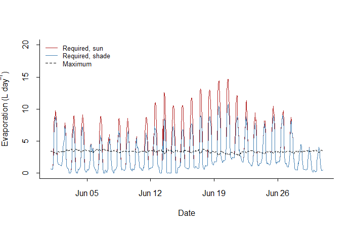

```r
# ----------------------- Lion in sun and in shade -------------------------- #
E_sun <- E_shade <- Emax <- numeric(720)
for (hr in 1:720) {
  shadedata <- micro[[hr]]
  shadedata$Rdirdown <- 0 # shade: direct beam blocked
  sun <- Endotherm(lion, tme[hr], micro[[hr]], lat, long, evapunits = "L/day")
  shade <- Endotherm(lion, tme[hr], shadedata, lat, long, evapunits = "L/day")
  E_sun[hr] <- sun$Lreq
  E_shade[hr] <- shade$Lreq
  Emax[hr] <- shade$Lmax
}

# ----------------------------- Plot results ------------------------------ #
tmec <- as.POSIXct(tme)
plot(E_sun ~ tmec, type = "l", col = "firebrick", ylim = c(0, 20),
     xlab = "Date", ylab = expression("Evaporation (L day"^-1 * ")"))
lines(E_shade ~ tmec, col = "steelblue")
lines(Emax ~ tmec, lty = 2) # most the lion can evaporate
legend("topleft", legend = c("Required, sun", "Required, shade", "Maximum"),
       col = c("firebrick", "steelblue", "black"), lty = c(1, 1, 2), bty = "n", cex = 0.8)
```

The `Endotherm` function returns the required metabolic rate, the evaporative loss needed to maintain core temperature, and the temperatures of the skin and coat surface. Evaporation can be expressed as heat loss (W), water loss (litres per day), or a percentage of body mass per day. The function also returns the animal’s limits: the highest metabolic rate it can sustain, and the most it can evaporate by panting at its fastest and, if it sweats, from fully wet skin. The latter depends on humidity, as moist air takes up less water. If the animal would need more than either, the function gives a warning, as it cannot then hold its core temperature.

In the example above, we can see that for much of the middle of the day, the evaporation required exceeds what the lion can achieve (dashed line), in both sun and shade. At its peak in sun, for example, the model predicts a requirement of about 15 litres per day against a capacity of about 3 litres per day. These are equivalent instantaneous rates, not the amount lost over an entire day. `Endotherm` gives a warning at these hours: the lion cannot hold its core temperature, and would need to reduce heat gain, for example by resting on cooler ground in deeper shade. In this hot month the lion never needs to raise its metabolic rate above basal, so metabolic rate is not shown.

#### How hot or cold the surroundings feel

`Endotherm` tells us what the animal must do, but not how hot or cold its surroundings feel to it. That is calculated by a separate function, `EndothermPET`, as the physiologically equivalent temperature (PET). PET was originally developed as a human thermal index (Höppe 1999), but applied to animals it also depends on their size, insulation and physiology, so different animals can experience the same environment very differently. Air temperature alone is a poor guide to how hot or cold an animal feels, as sunshine can make an animal feel warmer, while wind chill can make it feel cooler. PET combines these effects into a single temperature: essentially the indoor temperature it would need to be for the animal to experience an equivalent physiological thermal state as in the outdoor environment it is actually in. It is calculated in two steps. First, the animal makes heat at a fixed rate, by default twice its basal rate, and its core and skin settle at whatever temperatures balance the heat it makes against the heat it loses outdoors. Blood flow to the skin, sweating and panting respond to those temperatures, following the rules of Höppe’s (1999) model of the human body. Second, the animal, with the same core and skin temperatures, is placed indoors: in shade, in almost still air (0.1 m s<sup>-1</sup>), with walls and floor at air temperature and a vapour pressure of 1.2 kPa. PET is the air temperature there at which the animal loses heat as fast as it makes it. Humidity therefore matters: in humid air, sweating and panting cool the animal less, so its body runs warmer and PET is higher. Unlike `Endotherm`, `EndothermPET` lets core temperature change, so it also returns core temperature and gives a warning if it goes above or below what the animal can survive.

The next bit of code runs `EndothermPET` on the same hourly conditions, again in full sun and in shade.

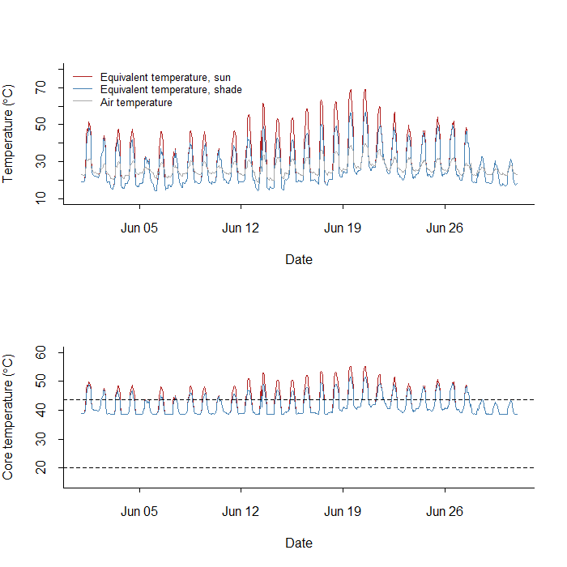

```r
# ----------------------- Lion in sun and in shade -------------------------- #
PET_sun <- PET_shade <- Tc_sun <- Tc_shade <- numeric(720)
for (hr in 1:720) {
  shadedata <- micro[[hr]]
  shadedata$Rdirdown <- 0 # shade: direct beam blocked
  sun <- EndothermPET(lion, tme[hr], micro[[hr]], lat, long)
  shade <- EndothermPET(lion, tme[hr], shadedata, lat, long)
  PET_sun[hr] <- sun$PET
  PET_shade[hr] <- shade$PET
  Tc_sun[hr] <- sun$Tcore
  Tc_shade[hr] <- shade$Tcore
}

# ----------------------------- Plot results ------------------------------ #
par(mfrow = c(2, 1))
plot(PET_sun ~ tmec, type = "l", col = "firebrick", ylim = c(10, 80),
     xlab = "Date", ylab = expression("Temperature (" * degree * "C)"))
lines(PET_shade ~ tmec, col = "steelblue")
lines(Tz_all ~ tmec, col = "darkgrey")
legend("topleft", legend = c("Equivalent temperature, sun",
                              "Equivalent temperature, shade", "Air temperature"),
       col = c("firebrick", "steelblue", "darkgrey"), lwd = 1, bty = "n", cex = 0.8)
plot(Tc_sun ~ tmec, type = "l", col = "firebrick", ylim = c(15, 60),
     xlab = "Date", ylab = expression("Core temperature (" * degree * "C)"))
lines(Tc_shade ~ tmec, col = "steelblue")
abline(h = c(lion$Tcmin, lion$Tcmax), lty = 2) # survivable limits
```

In full sun, the lion’s predicted PET at midday rises as much as 30 °C above air temperature at 30 cm. Shade reduces this difference, but PET can still exceed air temperature by up to 18 °C. Blocking the direct beam does not remove radiation emitted or reflected by the hot ground. At night, PET drops up to 7 °C below air temperature as the animal loses radiant heat to the cooler sky. The lower panel shows the lion’s core temperature. On most days it rises above the highest the lion can survive (upper dashed line), in shade as well as in sun, and `EndothermPET` gives a warning. This is consistent with `Endotherm`: at the hours when the lion cannot evaporate as much as it needs to, its core temperature rises.

The endotherm models are intentionally simplified. `Endotherm` holds core temperature fixed, `EndothermPET` borrows its responses to heat and cold from a model of the human body, and both assume the coat is uniformly thick over the whole body. A more detailed treatment would allow for transient body heat storage, or permit a more complex geometric body shape to be represented as in the endotherm model implemented in `NicheMapR` (Kearney et al. 2021).

## Microclimate models

### micropoint

The `micropoint` package most closely replicates the modelling approaches outlined in this vignette. It is designed to derive microclimatic conditions or ectotherm body temperatures at single point locations and the majority of the functions are R wrappers for C++ code that replicates the R functions detailed in this vignette. It can thus be thought of as a fast version of the `microclimlearn` package designed for practical use. It supersedes the `microclimc` package (Maclean & Klinges 2021), updating the treatment of below-canopy microclimate processes and improving computational efficiency through the use of underlying C++ implementations.

The package is still being developed, so its functions may occasionally change. It is installed as follows, and the last line opens a tutorial bundled with the package:

```r
require(devtools) # Install from CRAN if not already installed
devtools::install_github("ilyamaclean/micropoint")
library(micropoint)
vignette("new_model_tutorial", package = "micropoint")
```

An example output generated by the package is shown below. Here microclimatic temperatures are derived 5 cm above ground for a 10 cm grassland using the `micropoint::RunMicro` function over the course of a year (red) using the inbuilt climate dataset. Macroclimatic temperatures 2m above ground are shown in grey.

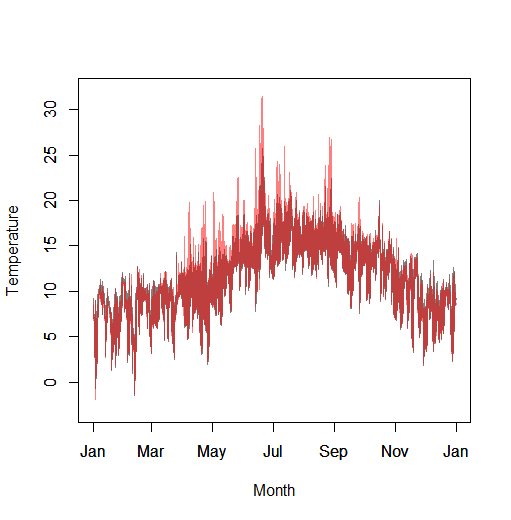

### microclimf

The `microclimf` package (Maclean 2026) extends `micropoint` to gridded applications and supersedes the microclimate components of the older package `microclima` (Maclean et al. 2019) by modelling microclimate entirely from first principles. It allows microclimate models to be run efficiently across landscapes. A key challenge is that conventional microclimate models require iterative solutions at each location, which becomes computationally expensive when applied to many grid cells. The `microclimf` model addresses this by exploiting a near-linear relationship between errors in non-iterative surface temperature estimates and the corresponding air–surface temperature difference. In practice, the model is run iteratively at a single reference location, and the resulting relationships are then used to estimate temperatures across the rest of the grid without iteration. Additional efficiencies are achieved in the treatment of vegetation. Rather than resolving detailed vertical canopy structure, microclimf assumes that total sensible and latent heat fluxes can be represented at the canopy scale, and that vertical transfer profiles follow a generalised analytical form. This avoids the need for explicit multilayer canopy representation while retaining the key effects of vegetation on below-canopy microclimate.

The latest version of the package is installed as follows:

```r
require(devtools) # Install from CRAN if not already installed
devtools::install_github("ilyamaclean/microclimf", ref = "dev")
library(microclimf)
```

Detailed instructions for using the package are bundled with it as a tutorial vignette:

```r
vignette("running-microclimf", package = "microclimf")
```

An example output generated using `microclimf::rungridmodelbig` function is shown below. Here temperatures 5 cm above ground at 2 pm on 1 June 2017 are modelled at 1m resolution for a 1×1km area around Caerthillian Cove, Cornwall, UK (49.968°N, 5.215°W).

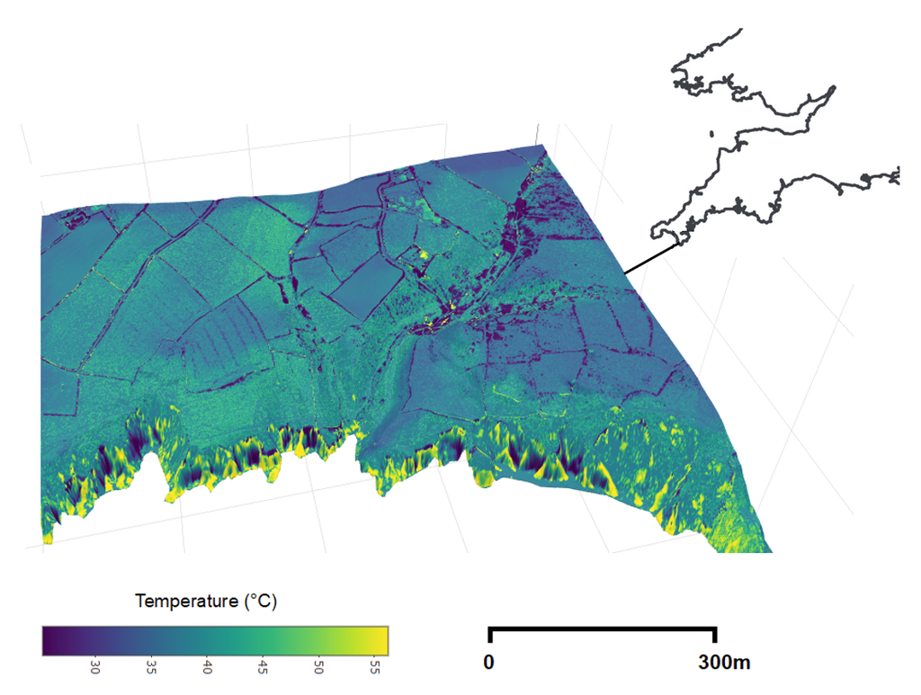

### mesoclim

So far, we have focused on the principles of microclimate modelling, deliberately excluding the downscaling of macroclimate data to finer spatial resolution. In other words, the emphasis has been on energy balance processes rather than adiabatic drivers of meso-scale climate variation, such as those associated with elevation or proximity to the coast.

The `mesoclim` package is designed for climate downscaling. It provides functions to account for processes such as cold-air drainage, as well as elevation and water-body effects on climatic conditions measured at weather stations. It also includes tools for temporal downscaling of climate datasets and for bias correction of future climate projections. It also contains a range of functions for basic processing of climate datasets such as infilling of coastal grid cells. In effect, it provides the necessary climate forcing data required to run microclimate models.

Detailed instructions for using the package are provided on its website, https://ilyamaclean.github.io/mesoclim/, as a series of four tutorials covering data preparation, spatial downscaling, temporal downscaling and bias correction. It is installed as follows:

```r
require(devtools) # Install from CRAN if not already installed
devtools::install_github("ilyamaclean/mesoclim")
library(mesoclim)
```

Below is an example figure generated with the aid of the `mesoclim` package. It shows side-by-side comparisons of mesoclim output downscaled to 100 m resolution and the original 1 km HadCRU data from the UK Met Office. The maps depict the fraction of years in which the Isles of Scilly (a small island archipelago off southwest UK; 49.9°N, 6.3°W) experience a subtropical climate (defined as at least eight months with a mean temperature of 10 °C or above). In addition to resolving fine-scale spatial structure, the mesoclim output fills gaps where coarse-resolution data are absent, particularly around coastlines and small islands, producing spatially continuous and more realistic climatic surfaces.

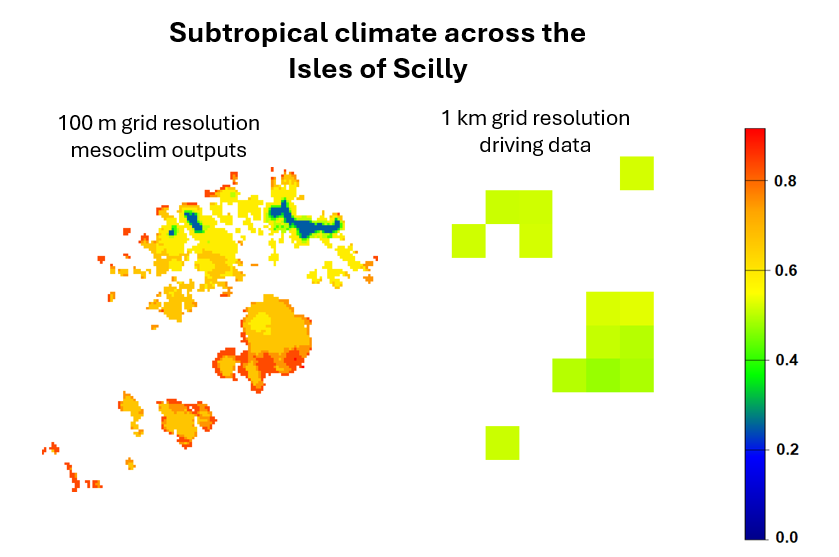

### microclimdata and mcera5

One of the main practical challenges in microclimate modelling is obtaining and preparing the required climate forcing, as well as vegetation and terrain predictor variables. The `mcera5` package (Klinges et al. 2022) provides convenient access to, and processing of, ERA5 climate data (from the ECMWF Copernicus Climate Data Store) for use in microclimate models. It can be installed as follows, and the package includes its own vignette explaining how to download and prepare the data.

```r
remotes::install_github(“dklinges9/mcera5”
library(mcera5)
```

The `microclimdata` package extends the capabilities of `mcera5`, enabling the download and processing of a wider range of climate datasets. It also provides tools for obtaining, processing, and generating the vegetation and soil data required for microclimate modelling, and for deriving the necessary model parameters. Together, these allow microclimate models to be run globally at spatial resolutions down to ~10 m.

Detailed instructions for using the package are provided [here](https://rpubs.com/ilyamaclean/microclimdataguide). It is installed as follows:

```r
require(devtools) # Install from CRAN if not already installed
devtools::install_github("ilyamaclean/microclimdata")
library(microclimdata)
```

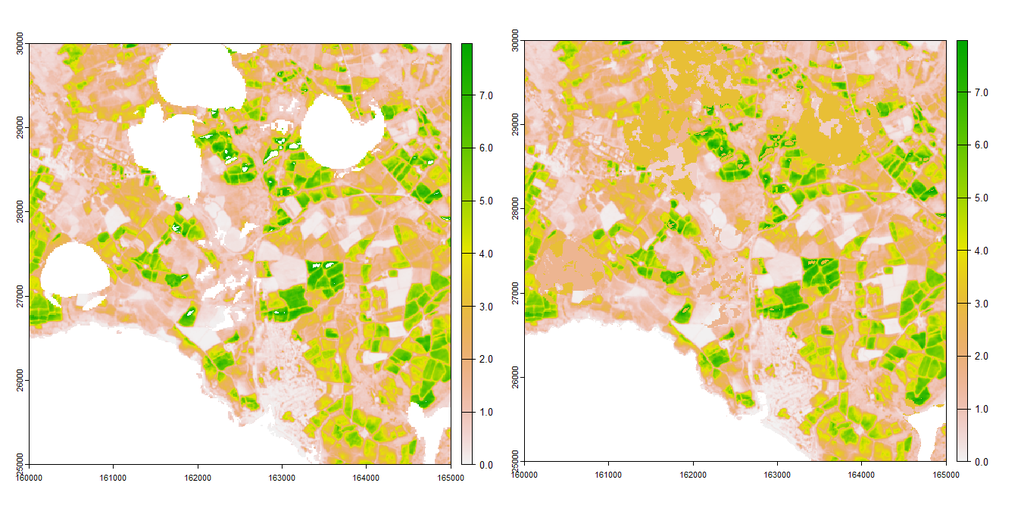

### NicheMapR

The NicheMapR package (Kearney & Porter 2017) is a comprehensive biophysical modelling framework that links microclimate conditions to organismal heat, water and energy balance. It is built around a set of well-established Fortran models, wrapped in R, and is widely used for mechanistic niche modelling—that is, predicting where species can persist based on first-principles representations of how environmental conditions interact with organism physiology, rather than relying on statistical correlations with observed distributions.

The package comprises three main components. The microclimate model (Kearney & Porter 2017) predicts hourly above- and below-ground environmental conditions from meteorological, terrain and soil inputs, including soil temperature and moisture profiles. It also includes an explicit treatment of snow, allowing simulation of snow accumulation and melt and their effects on ground temperatures and thermal buffering during winter. The underlying processes and formulations are very similar to those described in this vignette—particularly for soil heat and water dynamics. The main difference is that below-canopy microclimate is not resolved explicitly; instead, canopy effects are represented more simply through a shading factor that modifies the amount of radiation reaching the ground. These outputs form the environmental inputs for the organism models.

The ectotherm model uses these microclimate predictions to solve the heat and water balance of ectothermic organisms, estimating body temperature, activity, water loss and behavioural responses based on specified morphological and physiological traits (Kearney & Porter 2019). The underlying heat balance is formulated in a very similar way to that described in this vignette. The model can also represent transient heat exchange, including single- and two-compartment (“lumped”) formulations that allow internal temperature gradients to be represented, which is important for larger organisms. It can be coupled to Dynamic Energy Budget (DEB) theory to simulate growth, development and reproduction through time. In simple terms, DEB models describe how organisms acquire energy from food and then use it—first to meet basic maintenance costs, and then, if sufficient energy remains, to support growth and reproduction—allowing physiological performance to be linked directly to environmental conditions.

The endotherm model extends this approach to homeothermic organisms, solving for the metabolic rate and water loss required to maintain a stable core body temperature under given environmental conditions (Kearney et al. 2021). As in this vignette, it represents heat exchange between the organism and its environment, but goes further in its treatment of endotherm-specific physiology, explicitly accounting for traits such as fur or feather insulation and the temperatures of the body surface and insulating layer. Rather than providing a simple index of thermal stress, it is designed to predict the physiological requirements needed to maintain thermal balance under specified environmental conditions.

Together, these components provide a flexible framework for linking climate to physiological performance and species distributions. However, as a point-based modelling system, NicheMapR is typically applied at individual locations rather than across spatial grids.

The package is extensively tested and documented and detailed instructions for downloading, installing and using it are provided [here](https://mrke.github.io/).

NicheMapR is now being rewritten in Julia, a programming language that is as easy to use as R but runs at speeds comparable to compiled languages such as Fortran or C++. The new framework, NicheMapper.jl (https://github.com/BiophysicalEcology/NicheMapper.jl), comprises a set of linked packages: Microclimate.jl, a conversion of the NicheMapR microclimate model; HeatExchange.jl, which calculates heat exchange between organisms and their environment; and MicroclimateMapper.jl, which runs the models across gridded environmental datasets as well as at single points. The below-canopy model of `micropoint` is also being incorporated, so the Julia version will resolve below-canopy microclimate explicitly. The packages are still at an early stage of development.

Because these packages are written in Julia, and are not yet registered as Julia packages, they are installed and used differently from the R packages described here. Some tips for getting started:

1. Install Julia from https://julialang.org/downloads/. Code can be typed into the Julia console or written as scripts, for example in VS Code with its Julia extension.
2. The simplest way to install the packages is to download the BiophysicalEcologyEnv repository (https://github.com/BiophysicalEcology/BiophysicalEcologyEnv), which records a set of package versions that work together, and activate it from Julia:

```julia
using Pkg
Pkg.activate("path/to/BiophysicalEcologyEnv") # the folder the repository was downloaded to
Pkg.instantiate()                             # installs the packages: needed the first time only
using Microclimate, HeatExchange
```

3. The first time a function is used in a session, Julia compiles it, so the first run is slow and later runs are fast.
4. Help on a function is shown by typing `?` followed by its name in the Julia console. Documentation for Microclimate.jl is at https://BiophysicalEcology.github.io/Microclimate.jl/dev.
5. Julia can also be called from R using the `JuliaCall` package, though it is generally simpler to work in Julia directly.

### TrenchR

The TrenchR package (Buckley et al. 2023) provides a set of functions for modelling thermal environments and organismal heat exchange, primarily aimed at teaching and exploratory analyses. It implements relatively simple and modular microclimate and biophysical calculations, allowing users to examine how environmental conditions influence body temperature and heat fluxes under different scenarios.

Unlike NicheMapR and the workflow described in this vignette, TrenchR does not provide a fully integrated microclimate modelling framework. Instead, it offers modular functions for calculating individual processes (e.g. radiative and convective heat exchange), typically using simplified formulations. This makes it a useful educational resource, as assumptions and parameter dependencies are transparent and easy to explore.

A major strength of the package is its close integration with the open online textbook *Physical Processes in Ecosystems* by Buckley and colleagues. The book provides an accessible introduction to the physical principles underpinning ecological and microclimate processes, including radiation balance, heat transfer, mass transfer, fluid dynamics and organismal energy balance. TrenchR functions are used extensively throughout the text to demonstrate and explore these concepts interactively in R, making the package especially valuable for teaching and for developing intuition about how environmental and physiological processes interact.

The book is available here: https://bookdown.org/huckley/Physical_Processes_In_Ecosystems/

However, the representation of environmental conditions is relatively crude. In particular, TrenchR does not explicitly resolve below-canopy microclimate or coupled soil–vegetation–atmosphere processes, and is therefore less suited to spatially explicit or process-rich applications across heterogeneous landscapes.

Further details can be found here: https://trenchproject.github.io/TrenchR/

The package can also be installed from CRAN:

```r
install.packages("TrenchR")
library(TrenchR)
```

## References

Buckley LB, Briones Ortiz BA, Caruso I, John A, Levy O, Meyer AV, Riddell EA, Sakairi Y & Simonis JL (2023) TrenchR: An R package for modular and accessible microclimate and biophysical ecology. *PLOS Climate* 2: e0000139.

Calders K, Brede B, Newnham G, Culvenor D, Armston J, Bartholomeus H, Griebel A, Hayward J, Junttila S, Lau A, Levick S, Morrone R, Origo N, Pfeifer M, Verbesselt J & Herold M (2023) StrucNet: a global network for automated vegetation structure monitoring. *Remote Sensing in Ecology and Conservation* 9: 587–598.

Eller CB, Rowland L, Mencuccini M, Rosas T, Williams K, Harper A, Medlyn BE, Wagner Y, Klein T, Teodoro GS, Oliveira RS, Matos IS, Rosado BHP, Fuchs K, Wohlfahrt G, Montagnani L, Meir P, Sitch S & Cox PM (2020) Stomatal optimization based on xylem hydraulics (SOX) improves land surface model simulation of vegetation responses to climate. *New Phytologist* 226: 1622–1637.

Freeman MT, Czenze ZJ, Schoeman K & McKechnie AE (2020) Extreme hyperthermia tolerance in the world’s most abundant wild bird. *Scientific Reports* 10: 13098.

Hedstrom NR & Pomeroy JW (1998) Measurements and modelling of snow interception in the boreal forest. *Hydrological Processes* 12: 1611–1625.

Höppe P (1999) The physiological equivalent temperature – a universal index for the biometeorological assessment of the thermal environment. *International Journal of Biometeorology* 43: 71–75.

Kearney MR & Porter WP (2017) NicheMapR – an R package for biophysical modelling: the microclimate model. *Methods in Ecology and Evolution* 8: 664–674.

Kearney MR & Porter WP (2019) NicheMapR – an R package for biophysical modelling: the ectotherm model. *Ecography* 42: 85–96.

Kearney MR, Briscoe NJ, Mathewson PD & Porter WP (2021) NicheMapR – an R package for biophysical modelling: the endotherm model. *Ecography* 44: 1595–1605.

Kelliher FM, Leuning R, Raupach MR & Schulze E-D (1995) Maximum conductances for evaporation from global vegetation types. *Agricultural and Forest Meteorology* 73: 1–16.

Kleiber M (1947) Body size and metabolic rate. *Physiological Reviews* 27: 511–541.

Klinges DH, Duffy JP, Kearney MR & Maclean IMD (2022) mcera5: Driving microclimate models with ERA5 global gridded climate data. *Methods in Ecology and Evolution* 13: 1402–1411.

Maclean IMD (2026) Microclimf: Fast modelling of microclimate across real landscapes in R. *Methods in Ecology and Evolution* 17: 1112–1123.

Maclean IMD & Klinges DH (2021) Microclimc: A mechanistic model of above, below and within-canopy microclimate. *Ecological Modelling* 451: 109567.

Maclean IMD, Mosedale JR & Bennie JJ (2019) Microclima: An R package for modelling meso- and microclimate. *Methods in Ecology and Evolution* 10: 280–290.

Maia ASC, da Silva RG, de Souza Junior JBF, da Silva RB & Domingos HGT (2009) Effective thermal conductivity of the hair coat of Holstein cows in a tropical environment. *Revista Brasileira de Zootecnia* 38: 2218–2223.

Minnaar IA, Bennett NC, Chimimba CT & McKechnie AE (2014) Summit metabolism and metabolic expansibility in Wahlberg’s epauletted fruit bats (*Epomophorus wahlbergi*): seasonal acclimatisation and effects of captivity. *Journal of Experimental Biology* 217: 1363–1369.

Raupach MR (1989a) Applying Lagrangian fluid mechanics to infer scalar source distributions from concentration profiles in plant canopies. *Agricultural and Forest Meteorology* 47: 85–108.

Raupach MR (1989b) A practical Lagrangian method for relating scalar concentrations to source distributions in vegetation canopies. *Quarterly Journal of the Royal Meteorological Society* 115: 609–632.

Scholander PF, Walters V, Hock R & Irving L (1950) Body insulation of some arctic and tropical mammals and birds. *Biological Bulletin* 99: 225–236.

Sturm M, Taras B, Liston GE, Derksen C, Jonas T & Lea J (2010) Estimating snow water equivalent using snow depth data and climate classes. *Journal of Hydrometeorology* 11: 1380–1394.